# Digital expression explorer data stats

Chirag Parsania

7/1/2019

### Load library

```r
library(tidyverse)
```

### Let’s have a look to Dee derieved SRA meta data

DEE SRA meta data is given under the file name *_accession.tsv

```r
data_dir <- "/Users/chiragparsania/Documents/Projects/1_My_PhD/9_bioseqc/SRA_data_processing/dee_data/Scerevisiae/"
dee_meta_data_file <- list.files(data_dir , pattern = "*_accessions.tsv$" , full.names = T)
dee_sra_meta_data <- read_delim(file = dee_meta_data_file , delim = "\t") %>% as_tibble()
glimpse(dee_sra_meta_data)
```

```
## Observations: 8,378
## Variables: 8
## $ SRR_accession    <chr> "ERR1158090", "SRR527798", "SRR1583836", "SRR40…
## $ QC_summary       <chr> "FAIL(3,4,5,6,7)", "PASS", "FAIL(6,7)", "WARN(8…
## $ SRX_accession    <chr> "ERX1231497", "SRX171208", "SRX708680", "SRX200…
## $ SRS_accession    <chr> "ERS991201", "SRS352093", "SRS707749", "SRS1602…
## $ SRP_accession    <chr> "ERP013410", "SRP007949", "SRP047416", "SRP0809…
## $ GSE_accession    <chr> NA, "GSE31601", "GSE61665", NA, NA, "GSE54748",…
## $ GSM_accession    <chr> NA, "GSM977850", "GSM1510493", NA, NA, "GSM1323…
## $ experiment_title <chr> "Illumina HiSeq 2500 paired end sequencing", "G…
```

### Number of unique samples by different accession

By SRR_accession : 8378

By SRX_accession :7692

By SRP_accession : 448

By GSE_accession : 301

By GSM_accession :3933

As **SRR_accession** is equal to the number of rows in the table (sra_meta_data), **SRR_accession** will be considered as primary id.

### Problem

The meta data given with dee under file name *_accessions.tsv does not have some of the important columns such as

1. genotype
2. strain
3. title
4. description
5. ……
6. ……

These columns are very important for FungiExpresZ user query search. Something needs to be done to derieve these columns.

### Steps to follow

- To get the desired meta data columns go through the steps given below.

**Aim :** Our aim here is to dowmload meta data information for **all fungal samples**.

1. Go to [https://www.ncbi.nlm.nih.gov/sra] SRA
2. Search key word “fungi”
3. From the top right select option “type_rnaseq” and filter “RNA” from the top left
4. **sra_run_table** can be downloaded by selecting the option `send to --> Run selector`. By default, NCBI only allow first 20k samples to send Run selector. To deal with this, data must be send into chunks to the `Run selector`. **How to define the chunks** ??? Selecting txonomic groups (bottom right on SRA page) with < 20k samples helps to deal with this situation.
5. Here, **sra_run_table** downloaded in to three different files. One thing to notice here is all three files does not have identical number of columns.

### Let’s have a look to SraRunTable data

### Import & Clean

```r
run_info_file <- list.files(path = "/Users/chiragparsania/Documents/Projects/1_My_PhD/9_bioseqc/SRA_data_processing/sra_run_info/", pattern = "*SraRunTable*" ,full.names = T )

cat(run_info_file ,sep = "\n")
```

```
## /Users/chiragparsania/Documents/Projects/1_My_PhD/9_bioseqc/SRA_data_processing/sra_run_info//SraRunTable-1.txt
## /Users/chiragparsania/Documents/Projects/1_My_PhD/9_bioseqc/SRA_data_processing/sra_run_info//SraRunTable-2.txt
## /Users/chiragparsania/Documents/Projects/1_My_PhD/9_bioseqc/SRA_data_processing/sra_run_info//SraRunTable-3.txt
```

```r
fungal_sra_run_table <- run_info_file %>%
  tibble(files = . ) %>%  ## get files in to tibble
  mutate(data = purrr::map( files ,  ~( data.table::fread(. ,sep = "\t", quote="") %>% ## read data and make them to a single tibble
                                          as_tibble() %>% gather(var, val,-Run)) )  ) %>%
  unnest() %>%
  dplyr::select(-files) %>%
  unique() %>%
  spread(var, val) %>%
  janitor::clean_names() %>%
  readr::type_convert()
glimpse(fungal_sra_run_table)
```

```
## Observations: 44,818
## Variables: 69
## $ run                <chr> "DRR001783", "DRR001784", "DRR001966", "DRR00…
## $ alias              <chr> NA, NA, NA, NA, NA, NA, NA, NA, NA, NA, NA, N…
## $ assay_type         <chr> "OTHER", "OTHER", "RNA-Seq", "RNA-Seq", "RNA-…
## $ assembly_name      <chr> NA, NA, NA, NA, NA, NA, NA, NA, NA, NA, NA, N…
## $ avg_spot_len       <dbl> 50, 50, 76, 76, 76, 76, 200, 200, 200, 200, 2…
## $ biome              <chr> NA, NA, NA, NA, NA, NA, NA, NA, NA, NA, NA, N…
## $ bio_project        <chr> "PRJDB27", "PRJDB27", "PRJDB2669", "PRJDB2669…
## $ bio_sample         <chr> "SAMD00006267", "SAMD00006268", "SAMD00013662…
## $ bio_sample_model   <chr> NA, NA, NA, NA, NA, NA, NA, NA, NA, NA, NA, N…
## $ broker_name        <chr> NA, NA, NA, NA, NA, NA, NA, NA, NA, NA, NA, N…
## $ center_name        <chr> "KIRIN", "KIRIN", "NIAS", "NIAS", "NIAS", "NI…
## $ collection_date    <chr> NA, NA, NA, NA, NA, NA, NA, NA, NA, NA, NA, N…
## $ consent            <chr> "public", "public", "public", "public", "publ…
```

[output cut: 56 more lines]

### Save `fungal_sra_run_table` object to .rds file for later use

```r
readr::write_rds(x = fungal_sra_run_table , path = "/Users/chiragparsania/Documents/Projects/1_My_PhD/9_bioseqc/SRA_data_processing/sra_run_info/fungal_sra_run_info_table.rds" ,compress = "gz")
```

### Visually summarise `fungal_sra_run_table`

### Is column `run` has unique elements ?

```r
fungal_sra_run_table  %>%
  dplyr::select(run) %>% group_by(run) %>% tally() %>% summarise(n_distinct(n))
```

```
## # A tibble: 1 x 1
##   `n_distinct(n)`
##             <int>
## 1               1
```

n_distinct(n) = 1 suggest column `run` has unique values

### Are these data only RNA-seq ?

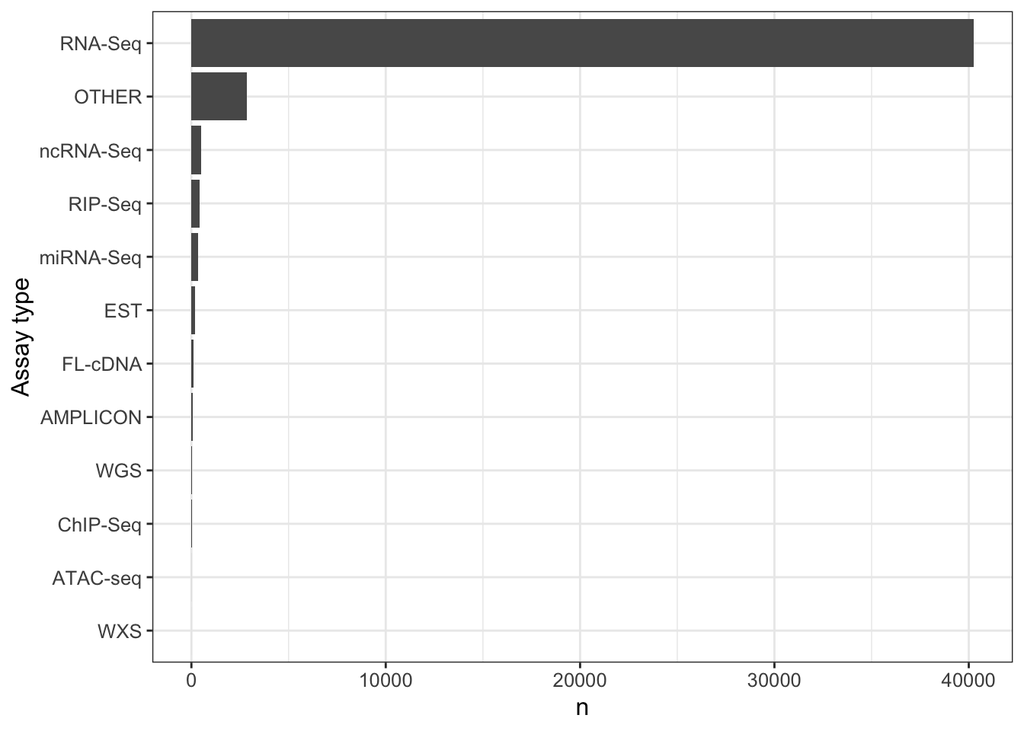

```r
seq_techno <- fungal_sra_run_table %>% group_by(assay_type) %>%tally(sort = T)
seq_techno %>% ggplot() + geom_bar(aes(x = fct_reorder(assay_type , n) , y = n) , stat = "identity") +coord_flip()+
  theme_bw() + theme(text = element_text(size = 12)) + xlab("Assay type")
```

### Plot top species by number of SRA RUN

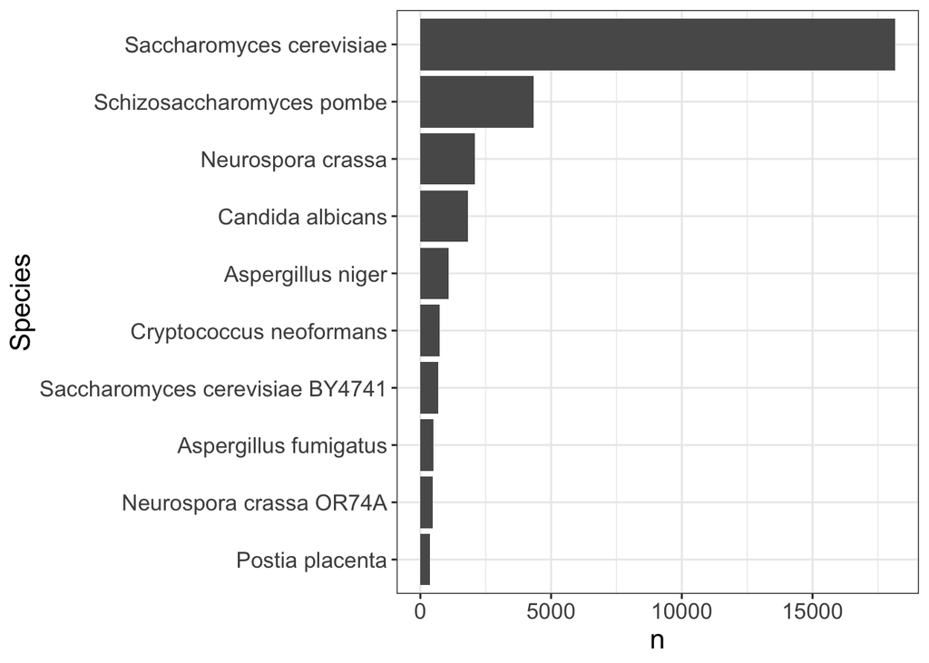

```r
count <- fungal_sra_run_table  %>%
  dplyr::select(organism_2 ) %>% dplyr::add_count(organism_2) %>% unique() %>% arrange(desc(n))

count %>% dplyr::slice(1:10) %>% ggplot(aes(x =  fct_reorder(organism_2 , n), y = n)) +
  geom_bar(stat = "identity") + coord_flip() + xlab("Species") + theme_bw() + theme(text = element_text(size = 15))
```

### Number of the samples sequenced over the year with different technology

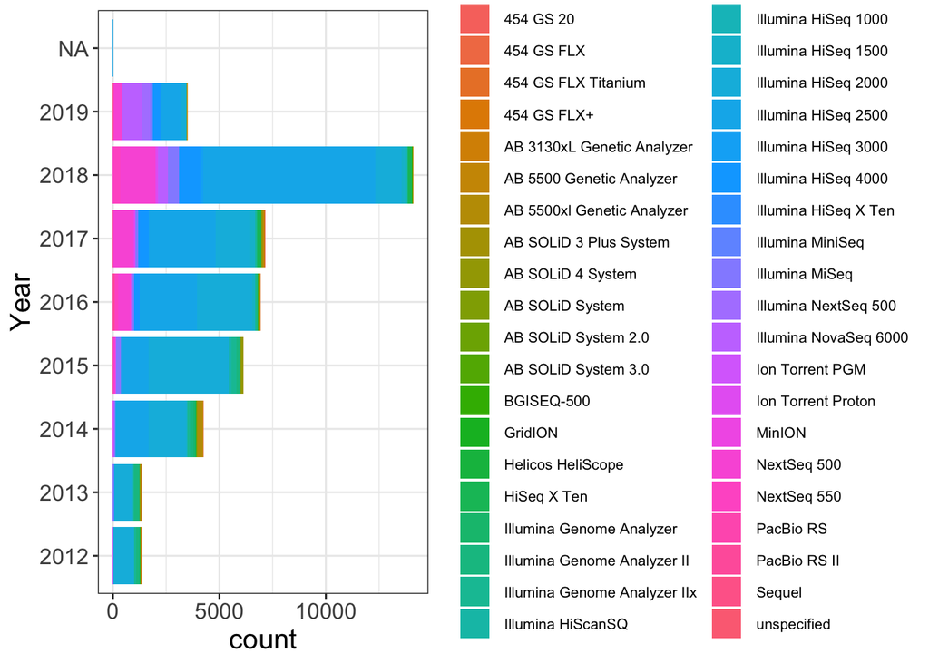

```r
fungal_sra_run_table %>% dplyr::select(load_date, instrument) %>% dplyr::mutate(year = lubridate::year(load_date)) %>% group_by(year) %>% add_count(sort = T) %>%
  ggplot(aes(x = fct_reorder(as.character(year) , year))) +
  geom_bar( aes(fill = instrument) , position = "stack") + coord_flip() + theme_bw() + theme(text = element_text(size = 15) ,legend.text = element_text(size = 8)) + xlab("Year")
```

### Now We have explored data enough. Let’s address original problem

### The next task is to prepare the gene expression table of dee data

### Prepare dee gene expression data and save into .rds objects.

```r
dee_gene_expression_file <- "/Users/chiragparsania/Documents/Projects/1_My_PhD/9_bioseqc/SRA_data_processing/dee_data/Scerevisiae/scerevisiae_ke.tsv"
dee_gene_expression_mat <- data.table::fread(dee_gene_expression_file,sep = "\t")
dee_long <- dee_gene_expression_mat %>%
  as_tibble() %>%
  mutate(V3 = log2(V3+1)) %>%
  mutate(org = "s_cerevisiae") %>%
  dplyr::rename("sample_name" = "V1" ,"geneName" = "V2" , "log2fpkm" = "V3") %>%
  filter(sample_name %in% fungal_sra_run_table$run) %>% ## keep those only, which has run information given in the fungal_run_table
  select(org , everything())

## save long
readr::write_rds(x = dee_long , path = "/Users/chiragparsania/Documents/Projects/1_My_PhD/9_bioseqc/SRA_data_processing/dee_data/Scerevisiae/dee_long.rds" ,compress = "gz")

## save wide
dee_wide <- dee_long %>% dplyr::select(-org) %>% spread(sample_name , log2fpkm)
readr::write_rds(x = dee_wide , path = "/Users/chiragparsania/Documents/Projects/1_My_PhD/9_bioseqc/SRA_data_processing/dee_data/Scerevisiae/dee_wide.rds" ,compress = "gz")

## save dee SRA data accession
dee_sra_accession <- dee_wide %>% colnames()%>% .[-1] %>% unique()
readr::write_rds(x = dee_sra_accession , path ="/Users/chiragparsania/Documents/Projects/1_My_PhD/9_bioseqc/SRA_data_processing/dee_data/Scerevisiae/dee_sra_accession.rds" ,compress = "gz")
```

### Dee data wide format loading time

```r
start_time <- Sys.time()
dee_expr_data <- readr::read_rds("/Users/chiragparsania/Documents/Projects/1_My_PhD/9_bioseqc/SRA_data_processing/dee_data/Scerevisiae/dee_wide.rds")
start_time - Sys.time()
```

### Dee data long format loading time

```r
start_time <- Sys.time()
dee_expr_data <- readr::read_rds("/Users/chiragparsania/Documents/Projects/1_My_PhD/9_bioseqc/SRA_data_processing/dee_data/Scerevisiae/dee_long.rds")
start_time - Sys.time()
```

### Prepare final sample info of Dee data

As fungal_sra_run_table contains many unnecessary columns, keep those which are informative.

```r
required_cols <- c("organism_2",
                   "strain",
                   "title",
                   "description",
                   "growth_condition",
                   "treatment",
                   "genotype",
                   "feature",
                   "experiment",
                   "host",
                   "temperature",
                   "geo_loc_name",
                   "insert_size",
                   "instrument",
                   "isol_growth_condt",
                   "library_name",
                   "library_layout",
                   "collection_date",
                   "run",
                   "bio_project",
                   "bio_sample",
                   "sample_name",
                   "sra_sample",
                   "sra_study")

dee_accession <- readr::read_rds("/Users/chiragparsania/Documents/Projects/1_My_PhD/9_bioseqc/SRA_data_processing/dee_data/Scerevisiae/dee_sra_accession.rds")

dee_data_sample_info <- fungal_sra_run_table %>%
  filter(fungal_sra_run_table$run %in%  dee_accession) %>% ## keep those only, which has run information given in the fungal_run_table
  select(required_cols)

dee_data_sample_info %>% glimpse()
```

```
## Observations: 11,821
## Variables: 24
## $ organism_2        <chr> "Saccharomyces cerevisiae", "Saccharomyces cer…
## $ strain            <chr> NA, NA, "HLUM", "HLM", "HLM", "HUM", "HUM", "H…
## $ title             <chr> NA, NA, NA, NA, NA, NA, NA, NA, NA, NA, NA, NA…
## $ description       <chr> NA, NA, NA, NA, NA, NA, NA, NA, NA, NA, NA, NA…
## $ growth_condition  <chr> NA, NA, NA, NA, NA, NA, NA, NA, NA, NA, NA, NA…
## $ treatment         <chr> NA, NA, NA, NA, NA, NA, NA, NA, NA, NA, NA, NA…
## $ genotype          <chr> NA, NA, "HIS3, LEU2, URA3, MET15 knockout", "H…
## $ feature           <chr> NA, NA, NA, NA, NA, NA, NA, NA, NA, NA, NA, NA…
## $ experiment        <chr> "ERX016943", "ERX016953", "ERX1174638", "ERX11…
## $ host              <chr> NA, NA, NA, NA, NA, NA, NA, NA, NA, NA, NA, NA…
## $ temperature       <chr> NA, NA, NA, NA, NA, NA, NA, NA, NA, NA, NA, NA…
## $ geo_loc_name      <chr> NA, NA, NA, NA, NA, NA, NA, NA, NA, NA, NA, NA…
## $ insert_size       <dbl> 0, 0, 230, 230, 230, 230, 230, 230, 230, 230, …
## $ instrument        <chr> "Illumina Genome Analyzer IIx", "Illumina Geno…
## $ isol_growth_condt <chr> NA, NA, NA, NA, NA, NA, NA, NA, NA, NA, NA, NA…
## $ library_name      <chr> "s_3_CATT_cDNA_FUN30", "s_3_GTAT_cDNA_WT", "Sa…
## $ library_layout    <chr> "SINGLE", "SINGLE", "PAIRED", "PAIRED", "PAIRE…
## $ collection_date   <chr> NA, NA, NA, NA, NA, NA, NA, NA, NA, NA, NA, NA…
## $ run               <chr> "ERR039794", "ERR039795", "ERR1095152", "ERR10…
## $ bio_project       <chr> "PRJEB2629", "PRJEB2629", "PRJEB11515", "PRJEB…
## $ bio_sample        <chr> "SAMEA1563964", "SAMEA1563955", "SAMEA3635380"…
## $ sample_name       <chr> "SAMEA1563964", "SAMEA1563955", "SAMEA3635380"…
## $ sra_sample        <chr> "ERS043747", "ERS043757", "ERS942529", "ERS942…
## $ sra_study         <chr> "ERP000806", "ERP000806", "ERP012912", "ERP012…
```

### Save dee data sample info

```r
readr::write_rds(x = dee_data_sample_info,  path ="/Users/chiragparsania/Documents/Projects/1_My_PhD/9_bioseqc/SRA_data_processing/dee_data/Scerevisiae/dee_data_sample_info.rds")
```

### Conclusions

1. Dee data expression mat saved in long and wide format
2. SRA all fungus run info table downloaded and saved as .rds
3. Dee data run info prepared and saved in the .rds data